- **Title: Real data CAPE Negative**
- **Output: html_document**
- **Reference: A guide to test association between Polygenic Risk Scores and psychological and psychiatric traits: practical examples**
- **Authors: Itziar Irigoien, Patricia Mas, Araceli Rosa, and Concepción Arenas**

## **Real data CAPE Negative**

- **In this real data set there are 106 PRS, and a continuous Trait (CAPE_Negative), with gender, age, and two Principal Components as covariates.**
- **Data reading**

```r
dat <- read.table("Real_data_Negative.csv", header=TRUE, sep="\t", dec=".")
names(dat) #
```

```
##   [1] "ID"            "Sex"           "Age"           "CAPE_Negative"
##   [5] "PRS.1"         "PRS.2"         "PRS.3"         "PRS.4"
##   [9] "PRS.5"         "PRS.6"         "PRS.7"         "PRS.8"
##  [13] "PRS.9"         "PRS.10"        "PRS.11"        "PRS.12"
##  [17] "PRS.13"        "PRS.14"        "PRS.15"        "PRS.16"
##  [21] "PRS.17"        "PRS.18"        "PRS.19"        "PRS.20"
##  [25] "PRS.21"        "PRS.22"        "PRS.23"        "PRS.24"
##  [29] "PRS.25"        "PRS.26"        "PRS.27"        "PRS.28"
##  [33] "PRS.29"        "PRS.30"        "PRS.31"        "PRS.32"
##  [37] "PRS.33"        "PRS.34"        "PRS.35"        "PRS.36"
##  [41] "PRS.37"        "PRS.38"        "PRS.39"        "PRS.40"
##  [45] "PRS.41"        "PRS.42"        "PRS.43"        "PRS.44"
##  [49] "PRS.45"        "PRS.46"        "PRS.47"        "PRS.48"
##  [53] "PRS.49"        "PRS.50"        "PRS.51"        "PRS.52"
##  [57] "PRS.53"        "PRS.54"        "PRS.55"        "PRS.56"
##  [61] "PRS.57"        "PRS.58"        "PRS.59"        "PRS.60"
##  [65] "PRS.61"        "PRS.62"        "PRS.63"        "PRS.64"
##  [69] "PRS.65"        "PRS.66"        "PRS.67"        "PRS.68"
##  [73] "PRS.69"        "PRS.70"        "PRS.71"        "PRS.72"
##  [77] "PRS.73"        "PRS.74"        "PRS.75"        "PRS.76"
##  [81] "PRS.77"        "PRS.78"        "PRS.79"        "PRS.80"
##  [85] "PRS.81"        "PRS.82"        "PRS.83"        "PRS.84"
##  [89] "PRS.85"        "PRS.86"        "PRS.87"        "PRS.88"
##  [93] "PRS.89"        "PRS.90"        "PRS.91"        "PRS.92"
##  [97] "PRS.93"        "PRS.94"        "PRS.95"        "PRS.96"
## [101] "PRS.97"        "PRS.98"        "PRS.99"        "PRS.100"
## [105] "PRS.101"       "PRS.102"       "PRS.103"       "PRS.104"
## [109] "PRS.105"       "PRS.106"       "PC1"           "PC2"
```

```r
dat <- dat[, -1]
```

- **Check that all variables you are interested in are properly read and that there are not other variables you do not need**
- **Do not forget to declare the categorical variables as factors**

```r
dat$Sex <- as.factor(dat$Sex)
```

- **Step 1: Order the PRSs**

```r
out <- orderR2(dat, yname="CAPE_Negative", prsname = "PRS.")
head(out)
```

```
##            Model1     Model2        Sum
## PRS.13 0.04743339 0.04930427 0.09673766
## PRS.12 0.04450825 0.04791485 0.09242311
## PRS.14 0.04102906 0.04398352 0.08501259
## PRS.70 0.03997513 0.04044623 0.08042136
## PRS.65 0.03986674 0.04044801 0.08031474
## PRS.69 0.03990297 0.04039181 0.08029478
```

```r
mainfilename <- "Real_example_CAPE_Negative"
filename <- paste0(mainfilename, "_Ordered_PRS.csv")
write.csv2(out,file=filename)
```

- **Step 1: Plot the sum of coefficients of determination $S_{R^2}$. Lines: in blue the median; in black the mean**

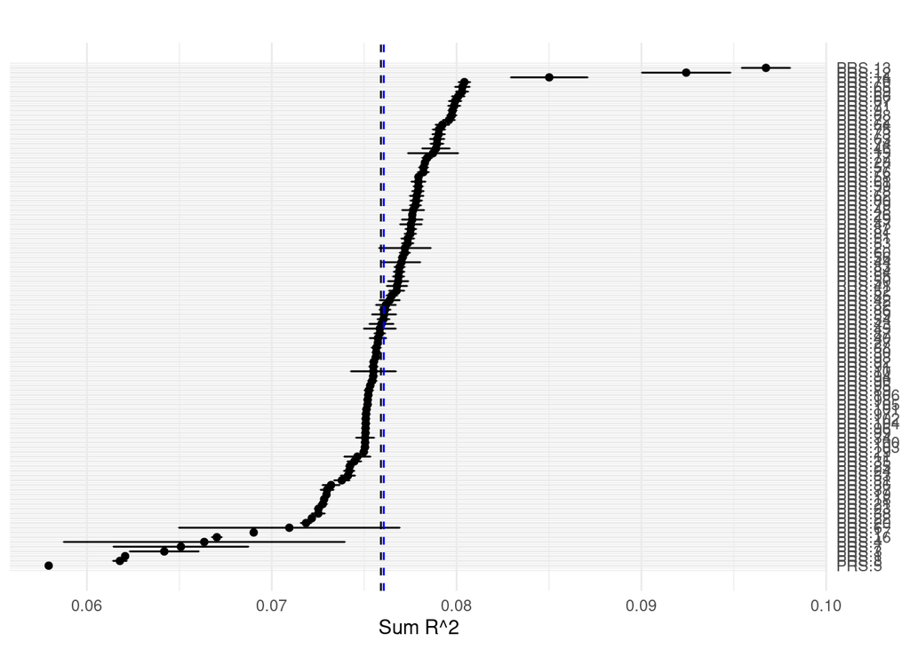

```r
out <- data.frame(out)
nPRS <- dim(out)[1]
select <- grep("Model", names(out), value=FALSE)
out$effect <- out$Sum
sds <- apply(out[, select], 1, sd)
out$lower <- out$effect - sds
out$upper <- out$effect + sds
out$rank <- nPRS:1

n <- dim(out)[1]
ggplot(data=out, aes(y=rank, x=effect, xmin=lower, xmax=upper)) +
  geom_point() +
  geom_errorbarh(height=.1) +
  scale_y_continuous(name=NULL, breaks= n:1, labels=row.names(out), position="right") +
  labs(title='', x='Sum R^2', y = 'PRS') +
  geom_vline(xintercept=mean(out$effect), color='black', linetype='dashed') +
  geom_vline(xintercept=median(out$effect), color='blue', linetype='dashed') +
  theme_minimal()
```

- **Repeat the plot with only de PRS with $S_{R^2}$ larger then the median. Lines: in red and solid the 95% percentile; in red and dashed the 90%, 85%, 80% percentiles**

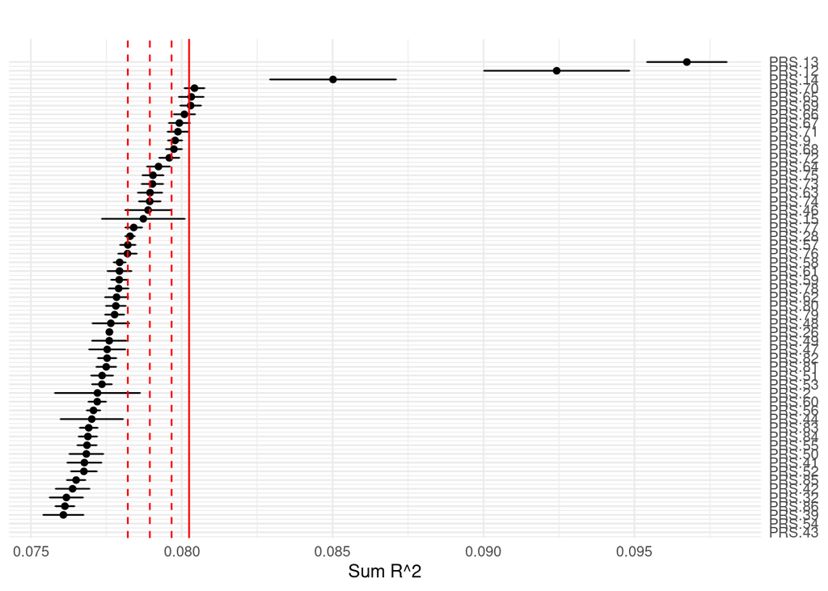

```r
sel <- out$Sum > median(out$effect)
ggplot(data=out[sel,], aes(y=rank, x=effect, xmin=lower, xmax=upper)) +
  geom_point() +
  geom_errorbarh(height=.1) +
  scale_y_continuous(name=NULL, breaks= n:1, labels=row.names(out), position="right") +
  labs(title='', x='Sum R^2', y = 'PRS') +
  geom_vline(xintercept=quantile(out$Sum, prob=0.95), color='red', linetype='solid') +
  geom_vline(xintercept=quantile(out$Sum, prob=c(0.80, 0.85, 0.90)), color='red', linetype='dashed') +
  theme_minimal()
```

- **Create files with PRS with the sum of $R^2$ greater then the 95%, 90%, 85% and 80% percentile**

```r
sel_95 <- out$Sum > quantile(out$Sum, prob=0.95)
write.csv2(out[sel_95,-9], file="CAPE_Negative_percentil_95.csv")
sel_90 <- out$Sum > quantile(out$Sum, prob=0.90)
write.csv2(out[sel_90,-9], file="CAPE_Negative_percentil_90.csv")
sel_85 <- out$Sum > quantile(out$Sum, prob=0.85)
write.csv2(out[sel_85,-9], file="CAPE_Negativ_85.csv")
sel_80 <- out$Sum > quantile(out$Sum, prob=0.80)
write.csv2(out[sel_80,-9], file="CAPE_Negativ_80.csv")
```

- **According to the obtained results, first, PRS.13 is selected to analyse its possible association with the CAPE_Negative**
- **Step 2.1: Plots to check the possible interactions**

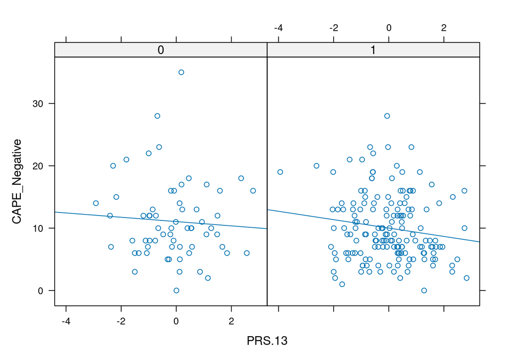

```r
# First candidate PRS.13
# Plot it
library(lattice)
xyplot(CAPE_Negative~PRS.13|Sex, data=dat,  type=c("p", "r"))
```

- **The plots suggest that the interaction between the PRS.13 and the sex is not relevant. Thus, we set the full model candidate (FM): $CAPENegative \sim PRS + Sex + Age + PC1 +PC2$**
- **Step2.2: Do parametric assumptions for the selected FM hold?**

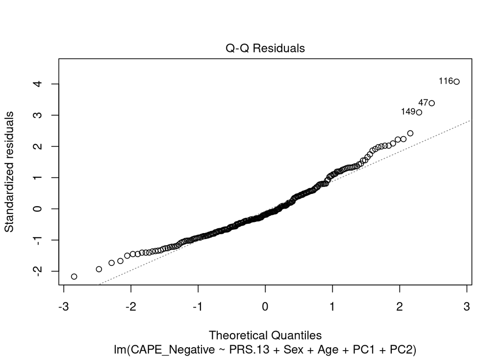

```r
#model
FM <- lm(CAPE_Negative ~ PRS.13 + Sex + Age + PC1 + PC2, data=dat)
#qq-plot for normality
plot(FM,2)
```

```r
#Saphiro-Wilk test
shapiro.test(FM$residuals)
```

```
##
##  Shapiro-Wilk normality test
##
## data:  FM$residuals
## W = 0.95885, p-value = 4.335e-06
```

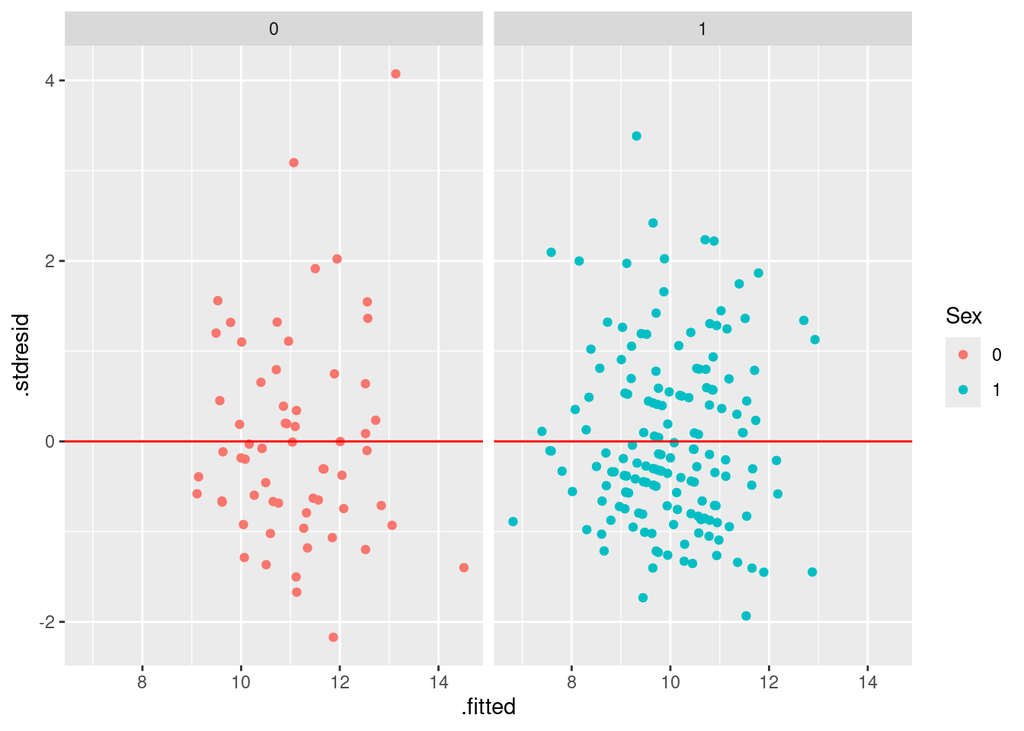

```r
#plot for variances
d <- fortify(FM)
ggplot(d,aes(x=.fitted, y=.stdresid, colour=Sex)) + geom_point() + geom_hline(yintercept=0, col="red")+
  facet_wrap(.~Sex)
```

```r
#Levene's test
leveneTest(.stdresid ~ Sex, data=d)
```

```
## Levene's Test for Homogeneity of Variance (center = median)
##        Df F value Pr(>F)
## group   1  0.7613 0.3839
##       224
```

- **It seems that there is lack of normality of residual but linearity and homocedasticity assumptions hold. Thus, we have two approaches to assess the possible association with PRS.13 and the Trait: try a transformation (**Step 4.1.1**) or perform a permutation test (**Step 4.1.2**)**
- **Step 4.1.1: Try a transformation of the dependent variable:**

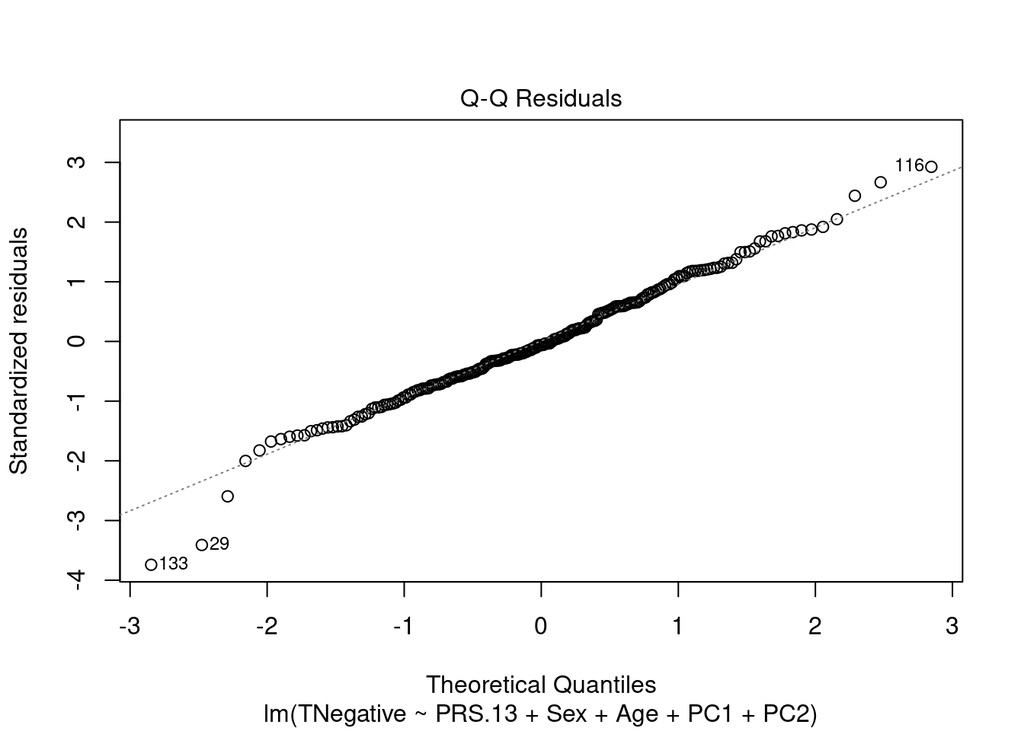

```r
dat$TNegative <- sqrt(dat$CAPE_Negative)
FM <- lm(TNegative ~ PRS.13 + Sex + Age + PC1 + PC2, data=dat)
#qq-plot for normality
plot(FM,2)
```

```r
#Shapiro-Wilk test
shapiro.test(FM$residuals)
```

```
##
##  Shapiro-Wilk normality test
##
## data:  FM$residuals
## W = 0.98898, p-value = 0.08108
```

- **Since it is suggested the transformation offered a solution for the lack of normality, the model we build is given by:**

```r
summary(FM)
```

```
##
## Call:
## lm(formula = TNegative ~ PRS.13 + Sex + Age + PC1 + PC2, data = dat)
##
## Residuals:
##     Min      1Q  Median      3Q     Max
## -3.2590 -0.5534 -0.0529  0.5640  2.5020
##
## Coefficients:
##              Estimate Std. Error t value Pr(>|t|)
## (Intercept)  3.013198   0.467855   6.440 7.39e-10 ***
## PRS.13      -0.101131   0.050141  -2.017   0.0449 *
## Sex1        -0.142137   0.133729  -1.063   0.2890
## Age          0.008634   0.021935   0.394   0.6943
## PC1          3.796970   4.232105   0.897   0.3706
## PC2          8.408721   4.206204   1.999   0.0468 *
## ---
## Signif. codes:  0 '***' 0.001 '**' 0.01 '*' 0.05 '.' 0.1 ' ' 1
##
## Residual standard error: 0.8837 on 220 degrees of freedom
##   (1 observation deleted due to missingness)
## Multiple R-squared:  0.04105,    Adjusted R-squared:  0.01926
## F-statistic: 1.884 on 5 and 220 DF,  p-value: 0.09824
```

- **The results show that PRS.13 is related with the sqrt(Trait) in the following way:**

$$\widehat{sqrt(Trait)} = 3.013 -
0.101\times PRS.13 - 0.142\times Sex + 0.009\times Age + 3.797\times PC1
+ 8.409\times PC2$$

- **Step 4.1.2: Perform a permutation test to assess the association**

```r
NM <- lm(CAPE_Negative ~  Sex + Age + PC1 + PC2, data=dat)
FM <- lm(CAPE_Negative ~ PRS.13 + Sex + Age + PC1 + PC2, data=dat)
outperm <- dR2(NullModel=NM, FullModel=FM, B=5000, seed=165)
outperm
```

```
## $dR2
## [1] 0.01964777
##
## $pvalue
## [1] 0.033
```

- ** We observe an increase of 0.0196 in the coefficient of determination when the PRS.13 is included in the model and the permutation test indicates it is significant.**
- **Last step: We move to the next PRS**